# Modelação Estocástica Problem Set 1

Resolução

CDC1 | Marco Delgado Esperança 110451 | Umeima Adam Mahomed 99239

#### **1. Pretende-se que gere 10.000 números pseudo-aleatórios provenientes da distribuição triangular:**

##### **(a)** Recorra ao método da aceitação-rejeição.

##### **(b)** Crie uma função de raiz para definir a distribuição triangular.

Note que a distribuição triangular é definida por três parâmetros: min, o vértice inferior esquerdo do triângulo, max, o vértice inferior direito, e mode, o vértice superior.

A escolha de valores para os parâmetros é discricionária.

##### **(c)** Os resultados devem ser apresentados em matrix ou data.frame, para além de um output gráfico simples que permita visualizar a densidade aproximada dos números simulados.

##### **Definição das funções a utilizar daqui em diante para a pergunta 1:**

```r
triangular_density <- function(x, min, max, mode) {
  ifelse(x < min | x > max, 0,
         ifelse(x <= mode, 2 * (x - min) / ((max - min) * (mode - min)),
                2 * (max - x) / ((max - min) * (max - mode))))
}
```

```r
gerar_triangular <- function(n, min, max, mode) {
  x <- numeric(n)
  i <- 1
  while (i <= n) {
    x_candidate <- runif(1, min, max)
    y_candidate <- runif(1, 0, 1)
    if (y_candidate <= triangular_density(x_candidate, min, max, mode)) {
      x[i] <- x_candidate
      i <- i + 1
    }
  }
  return(x)
}
```

##### **Aplicação Exemplo 1 para os parâmetros: min: 2, max: 10 e moda: 3**

```r
# EXEMPLO 1:
set.seed(2023)

min_valor <- 2
max_valor <- 10
mode_valor <- 3

amostra <- gerar_triangular(10000, min_valor, max_valor, mode_valor)

resultado_1 <- data.frame(Valor = amostra)

# resultado_1 # descomentar se se pretender ver o dataframe
```

##### **Visualização dos resultados obtidos**

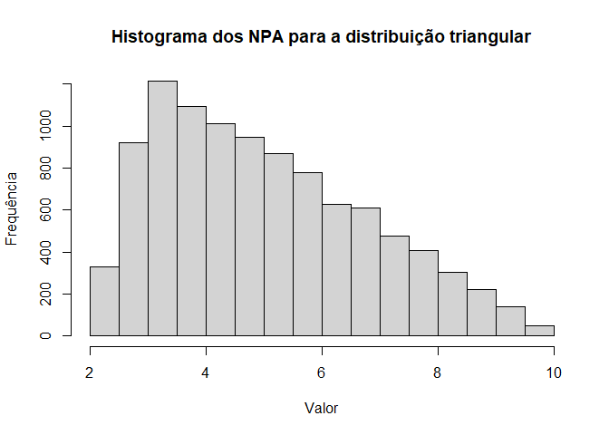

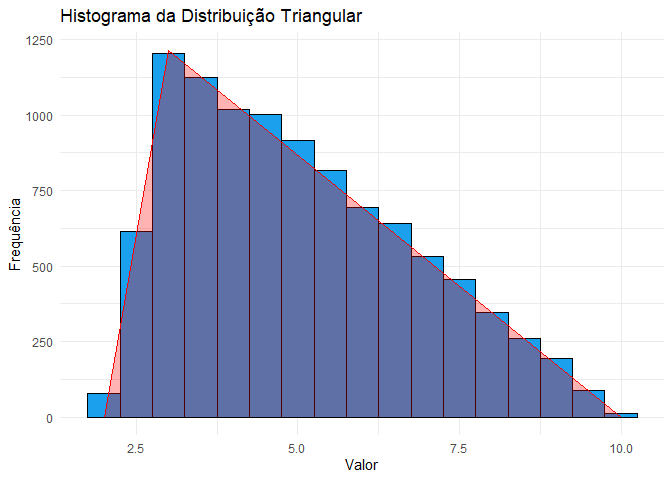

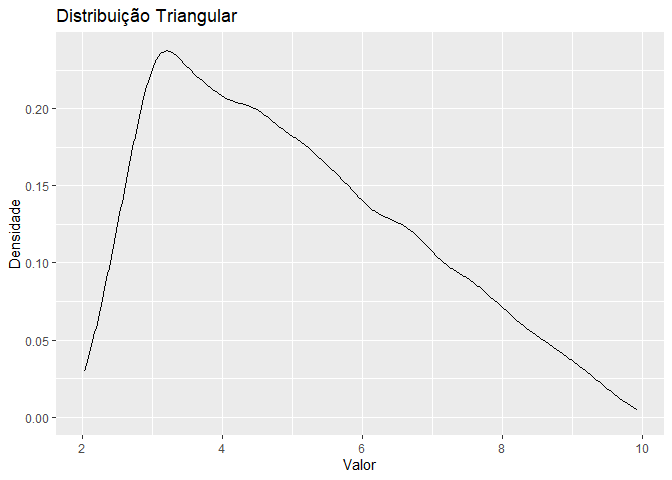

##### **Demonstração de uma visualização de uma parte dos dados que facilita a perceção do algoritmo para exemplo 1**

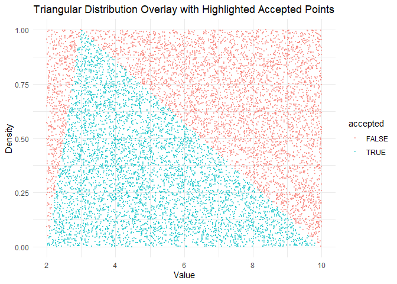

##### **Aplicação Exemplo 2 para os parâmetros: min: 0, max: 10 e moda: 5**

```r
# EXEMPLO 2:
set.seed(2023)

min_valor <- 0

max_valor <- 10

mode_valor <- 5

amostra <- gerar_triangular(10000, min_valor, max_valor, mode_valor)

resultado_2 <- data.frame(Valor = amostra)

# resultado_2 # descomentar se se pretender ver o dataframe
```

##### **Visualização dos resultados obtidos**

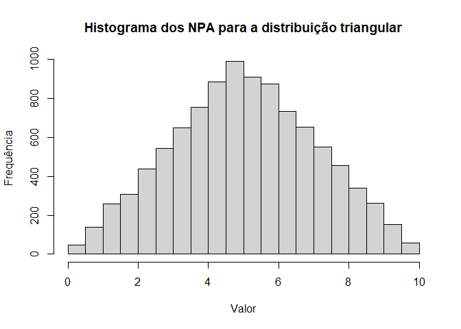

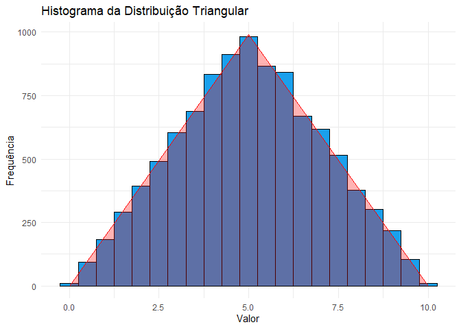

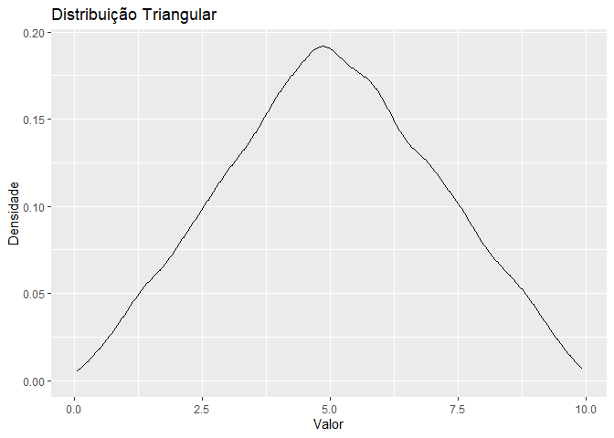

##### **Demonstração de uma visualização de uma parte dos dados que facilita a perceção do algoritmo para o exemplo 2**

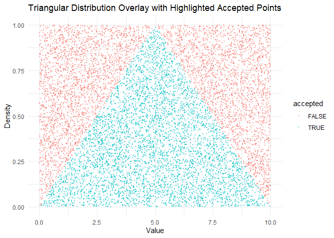

##### **Aplicação Exemplo 3 para os parâmetros: min: 5, max: 10 e moda: 8**

```r
# EXEMPLO 3:
set.seed(2023)

min_valor <- 5

max_valor <- 10

mode_valor <- 8

amostra <- gerar_triangular(10000, min_valor, max_valor, mode_valor)

resultado_3 <- data.frame(Valor = amostra)

#resultado_3 # descomentar se se pretender ver o dataframe
```

##### **Visualização dos resultados obtidos**

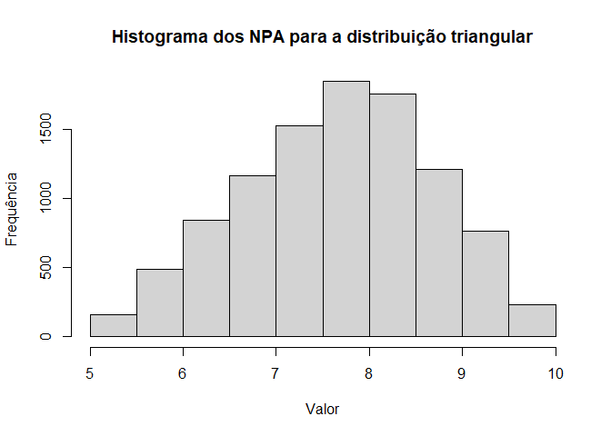

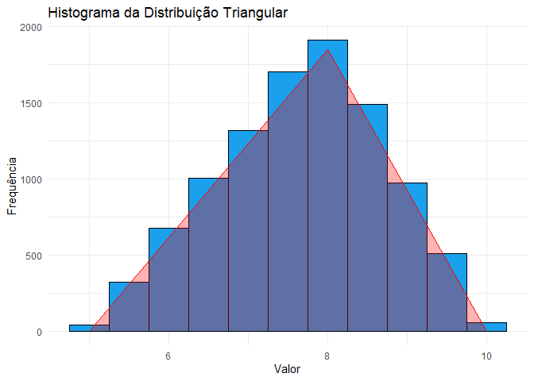

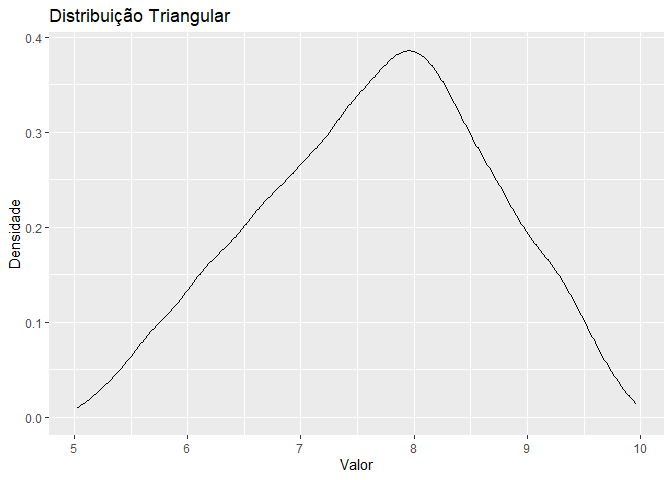

##### **Demonstração de uma visualização de uma parte dos dados que facilita a perceção do algoritmo para exemplo 3**

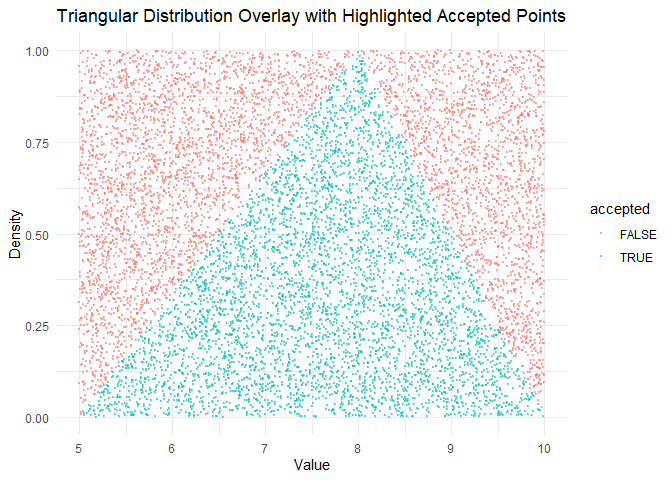

```r
# Junção das três distribuições triangulares geradas
dataf_triangulos <- cbind(resultado_1 , resultado_2, resultado_3)

colnames(dataf_triangulos) <- c("Exemplo 1", "Exemplo 2", "Exemplo 3")

#dataf_triangulos # descomentar se se pretender ver o dataframe
```

#### **2. Pretende-se que realize um estudo comparativo de dois estimadores para o coeficiente de assimetria de distribuições de probabilidade.**

#### **Considere os estimadores s1 e s2 para a assimetria de uma população qualquer:**

$$s_1 = \frac {Q_3 + Q_1 − 2Q_2}{Q_3 −
Q_1}$$
$$s_2 = \frac {(µ − ν)}{
E(|X − ν|) }$$

#### **em que, na Equação 1, Qi representa o quartil respectivo e, na Equação 2, µ corresponde à média e ν corresponde à mediana.**

##### **(a)** Gere, utilizando o gerador base do R para a distribuição t-student (rt()), e com set.seed(2023):

**i.** 100 amostras de dimensão n = 20

**ii.** 100 amostras de dimensão n = 100

**iii.** 100 amostras de dimensão n = 1000

##### **(b)** Obtenha, para cada amostra gerada e para cada estimador, a assimetria amostral (estimativa) correspondente.

##### **(c)** Recorrendo ao cálculo do erro-padrão e do erro quadrático médio, conclua pela sua preferência por um dos estimadores e comente o seu comportamento, em função da dimensão das amostras obtidas. Apresente os resultados num data.frame.

##### **Definições dos estimadores**

```r
# Definir a seed
set.seed(2023)

# Definir os tamanhos das amostras
tamanhos <- c(n = 20, n = 100, n = 1000)

# Definir as funções dos estimadores
calcular_s1 <- function(amostra) {

  q1 <- quantile(amostra, 0.25)

  q2 <- median(amostra)

  q3 <- quantile(amostra, 0.75)

  return ((q3 + q1 - 2*q2) / (q3 - q1))
}

calcular_s2 <- function(amostra) {

  media <- mean(amostra)

  mediana <- median(amostra)

  abs_diff <- abs(amostra - mediana)

  return ((media - mediana) / mean(abs_diff))
}
```

##### **Aplicação dos estimadores**

```r
# Criar listas para armazenar os resultados
resultados_s1 <- list()

resultados_s2 <- list()

erros <- list()

eficiencias <- list()

# Loop pelos tamanhos de amostra

for (n in tamanhos) {

  amostras <- replicate(100, rt(n = n, df = 5))

  assimetrias_estimador_1 <- (apply(amostras, 2, calcular_s1))

  assimetrias_estimador_2 <- (apply(amostras, 2, calcular_s2))

  erro_padrao_1 <- sd(assimetrias_estimador_1)

  erro_padrao_2 <- sd(assimetrias_estimador_2)

  erro_quad_1 <- mean(erro_padrao_1^2)

  erro_quad_2 <- mean(erro_padrao_2^2)

  resultados_s1[[as.character(n)]] <- assimetrias_estimador_1

  resultados_s2[[as.character(n)]] <- assimetrias_estimador_2

  erros[[as.character(n)]] <- data.frame(

    estimador = "s1",

    erro_padrao = erro_padrao_1,

    erro_quadrático_médio = erro_quad_1,

    estimador = "s2",

    erro_padrao = erro_padrao_2,

    erro_quadrático_médio = erro_quad_2
  )

  # calcula as eficiências de cada estimador para cada n amostra
  eficiencias[[as.character(n)]] <- data.frame(eficiencia = erro_quad_2 / erro_quad_1
  )
}

erros
```

```
## $`20`
##   estimador erro_padrao erro_quadrático_médio estimador.1 erro_padrao.1
## 1        s1   0.2806003            0.07873655          s2     0.2165991
##   erro_quadrático_médio.1
## 1              0.04691519
##
## $`100`
##   estimador erro_padrao erro_quadrático_médio estimador.1 erro_padrao.1
## 1        s1   0.1386274            0.01921757          s2    0.09604514
##   erro_quadrático_médio.1
## 1             0.009224669
##
## $`1000`
##   estimador erro_padrao erro_quadrático_médio estimador.1 erro_padrao.1
## 1        s1  0.04388808           0.001926164          s2     0.0298698
##   erro_quadrático_médio.1
## 1            0.0008922052
```

```r
eficiencias
```

```
## $`20`
##   eficiencia
## 1  0.5958502
##
## $`100`
##   eficiencia
## 1  0.4800123
##
## $`1000`
##   eficiencia
## 1  0.4632032
```

**Nota:** Considerou-se 5 graus de liberdade para a t de student de forma que, a comparação entre os estimadores S1 e S2 e as suas *n* amostras, seria mais facilitada. Além disso, conforme apontado, dado que se pretendia uma t de student, se os graus de liberdade fossem >30, haveria uma aproximação a uma normal, o que iria dificultar a comparação entre as métricas para cada estimador e *n* amostras sendo que alguns valores teriam de ser interpretados com esse fator em consideração.

Também foi feita uma experiência onde os graus de liberdade = n, ou seja, dependendo do *n* da amostra, os graus iriam diferir inter-amostra, onde foi observado que não exitia uma grande diferença entre os valores das métricas e os valores das métricas apresentados acima, tendo assim levado à decisão de deixar um valor constante (df = 5).

```r
# transformar os vetores para dataframes

dataf1 <- data.frame("20" = resultados_s1$`20`, "100" = resultados_s1$`100`, "1000" = resultados_s1$`1000`) # para estimador S1

dataf2 <- data.frame("20" = resultados_s2$`20`, "100" = resultados_s2$`100`, "1000" = resultados_s2$`1000`) # para estimador S2

colnames(dataf1) <- colnames(dataf2) <- c("Amostra: 20", "Amostra: 100", "Amostra: 1000" )

#dataf1 # descomentar se se pretender ver o dataframe

#dataf2 # descomentar se se pretender ver o dataframe
```

##### **Box plots para cada estimador e n amostras**

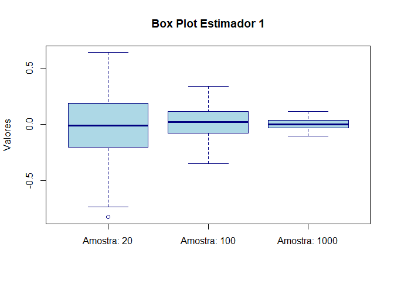

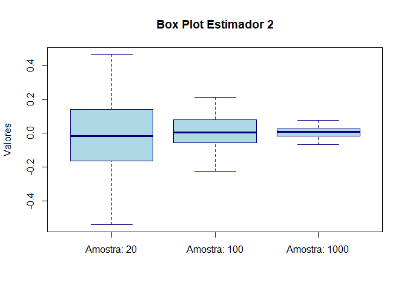

##### **Gráficos para o estimador 1**

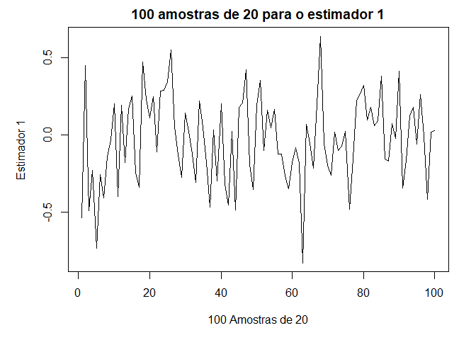

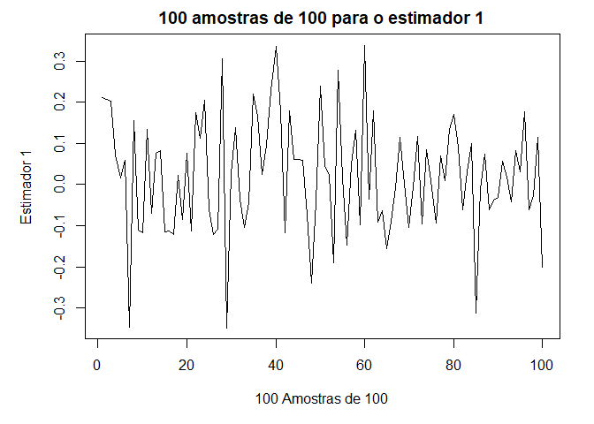

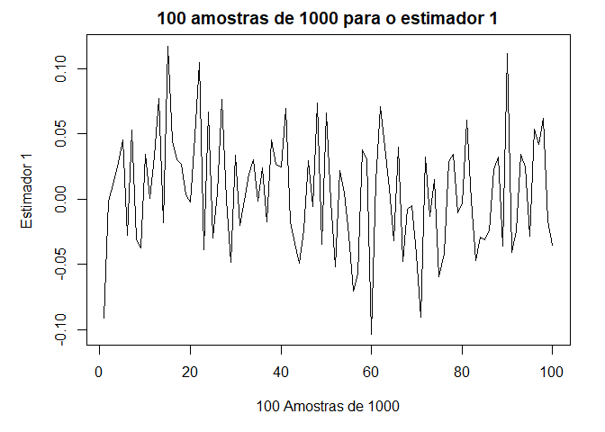

##### **Gráficos para o estimador 2**

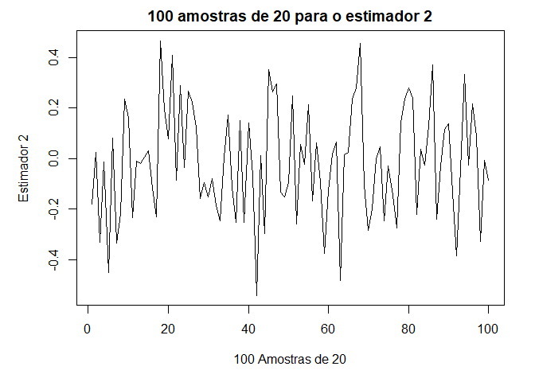

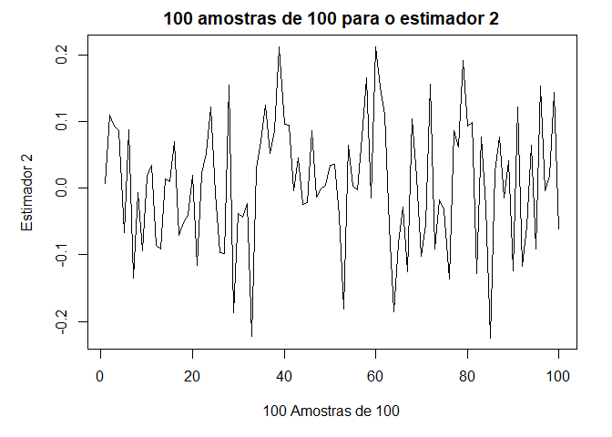

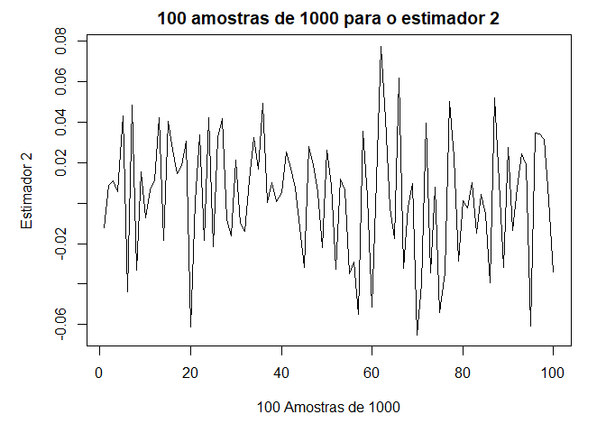

Com o que foi apresentado acima consegue-se obter uma melhor visualização da dispersão dos dados e perceber o comportamento dos dois estimadores em relação aos seus quartis.